# Quantified Self Report

13679042

Abhisek Gautam

23/09/2019

# 1. Introduction

Quantified Self (QS), a word coined in the year 2008 by a group of researchers and data enthusiasts has had a large number of followers since its introduction(Ferris, 2013). The primary motive of the philosophy is to gather data and analyse them to justify one’s behaviour, trends and habits so that one can change his/her behaviour so that he/she can lead a better life. The term QS is defined as “Quantified Self (QS) is the term that embodies self-knowledge through self-tracking” (Quantified Self Institute, 2017).

Our team, InnoData started collecting three types of data which could be used to check some behaviours that we had as a group. The types of data that were collected are as follows:

- GPS Data
- Mood Data
- Steps Count
- Messages (Individual Data)
- Rainfall (External Data)

In addition to that, two more datasets had been added, viz. my social media usage for my individual analysis and publicly available rainfall data of Sydney.

With these data, we wanted to answer three questions in our group:

1. Who in the group has travelled the most in Sydney?
2. Does happiness relate with steps count?
3. Who in the group prefers to walk and who doesn’t?

Some of the questions for my individual analysis are as follows:

1. Whether I used more social media on weekends, when I don’t have work?
2. Does my social media usage relate with my number of steps?

This report is made on the basis of the data that was collected in the period of six weeks.

# 2. Collection of Data

Our group started with brainstorming the types of data that could be collected easily and accurately. We decided to collect our GPS data, emotions, steps and call log history. We agreed using WhatsApp as our mode of communication and use Google drive to share our data. Our data was collected from 4th of August 2019 till 14th of September 2019. The process of collection of our group data is described below.

## 2.1 GPS

GPS data was readily available in all our smartphones, and its bulk could be downloaded from Google. Luckily, all of the team members had Android Smartphone, hence this data would be available for all. We agreed to have GPS location tracking enabled at all times. This data gave an account of our GPS positions at different times of the day.

## 2.2 Mood

For getting the mood data, we would take selfies at random times of the day and process them in a facial recognition software. Initially, we used an app called Feely, available on Play Store to get the emotions of individual photos. However, the results that were given by the app was not clear, so we switched to using Microsoft Azure API to calculate emotions. We would have eight emotions associated with the selfie photos now, as well as the datetime the photo was taken.

## 2.3 Steps Count

Initially, we decided to use an app called Pedometer to count our steps. Later on we found out that Google itself tracks our steps via Google Fit app. So, all of us switched from Pedometer to using Google’s Google Fit app. The data also could be downloaded from Google.

## 2.4 Individual Data- Messages in Messenger

Facebook’s Messenger data was collected to check my social media usage as it is the app that I use the most. The data could be extracted from Facebook for the period of this study.

## 2.5 External Data- Weather

Weather has a lot of affects in the movement of people. Hence, weather data of a station in Sydney was taken. Only daily rain was taken into account. The data is taken from Australian Government’s Bureau of Meteorology website, from the Sydney Observatory Hill weather station (“http://www.bom.gov.au/climate/data/index.shtml?bookmark=136”).

# 3. Data Processing and Quality Issues

All of the members of our group had shared their data in the Google drive. We then analysed individual data and tried to find out the issues that were prevalent in the collected data.

## 3.1 GPS

As our GPS was tracked by our smartphones, it was consistent and in detail. It records our GPS in regular intervals of time in a day, in KML format. The data was extracted and loaded in the dataframe, and was visualized by plotting in the map of Sydney. There were some outliers in the data, which may have been caused by inaccurate reading. From the Figure 1, we can see that there are some positions where GPS tracking had fluctuated and recorded random data some times. Additionally, the GPS data needed to be converted to standard datetime format so that it could be compared with data tracked on the basis of date and time.

[figure not shown]

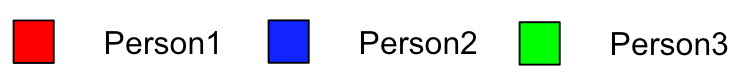

Figure 1: Location History of All Group Members

## 3.2 Mood

In the mood data, there were issues of consistency and error in reading the data. Here, we dealt with data inconsistency; as in some days, there were no photos taken, and some days had multiple photos. We had anticipated that the selfies would have a varying mood, but in reality, everyone was giving their neutral reaction while clicking their selfies So, besides a few photos, all of the moods returned by the mood detection API were seen to be on the neutral spectrum and hence we figured that this was inefficient to determine the mood of a person processing selfies.

## 3.3 Steps Count

For steps count, that the application that was used to track steps counted step even when we were not moving and sometimes it did not track any. Also, we don’t always carry our smartphones while walking, making this data somewhat inaccurate. Using FitBit devices would have helped overcoming the issues regarding inaccurate step count and it would have given more accurate readings.

## 3.4 Messenger

For individual data, Facebook’s messenger data gave the messages that were sent and received by me. Messenger, being my primary chatting application, would give a fair estimate of my social media usage. However, deleted conversations could not be obtained. The time of this data was converted to AEDT (Australian Eastern Daylight Time), and the number of messages sent per day was counted.

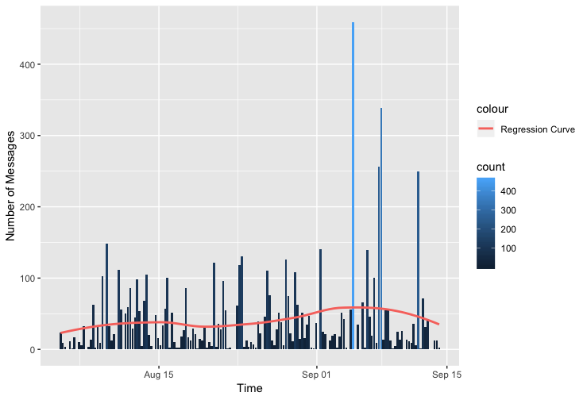

Figure 2: Plot showing Messages sent and received

## 3.5 Rainfall

The consideration with weather data was that if it showed rainfall, it was assumed for the entire region of Sydney. This is not accurate as one region may experience rainfall while another area may have a sunny weather. However, since the Sydney Observatory Hill weather station is located in the heart of Sydney, it was considered a fair assumption.

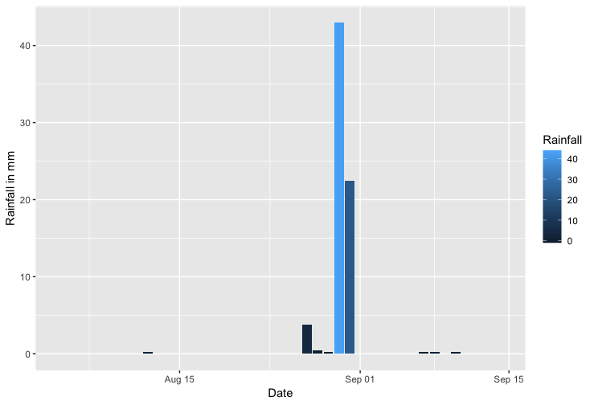

Figure 3: Visualization of Rainfall Data

# 4. Analysis and Insights

The obtained data is charted using R’s plotting functions keeping in mind our initial questions. Analysis of the plots are done and insights are formulated accordingly.

## 4.1 GPS

Looking at GPS data for the entire period of 6 weeks, from Figure 1, Person3 had explored Sydney the most.

[figure not shown]

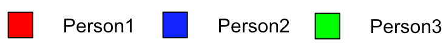

Figure 4: Visualization showing GPS data of 27th August, 2019

## 4.2 Steps

Figure 5 shows that Person3 walks the most in the group.

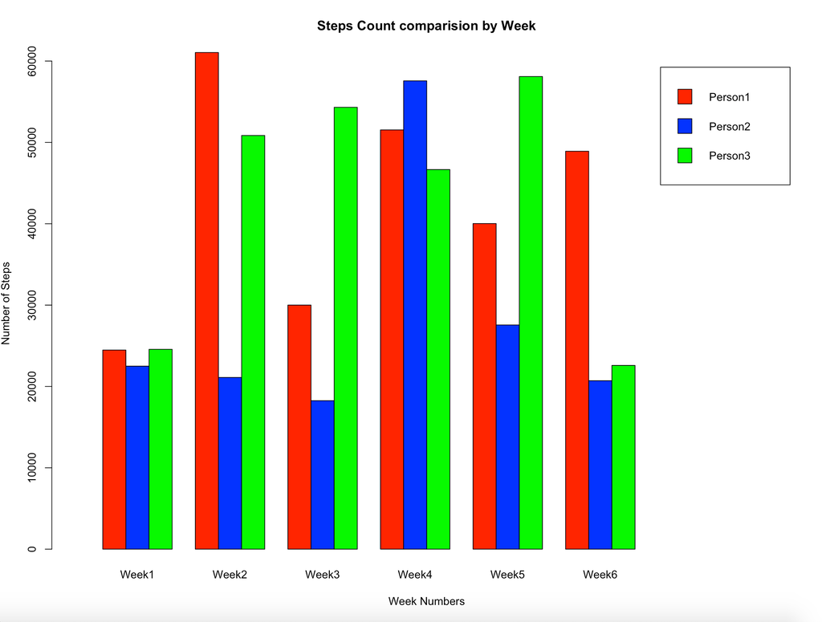

Figure 5: Steps Count of Group Members for different weeks

## 4.3 Steps and Rainfall

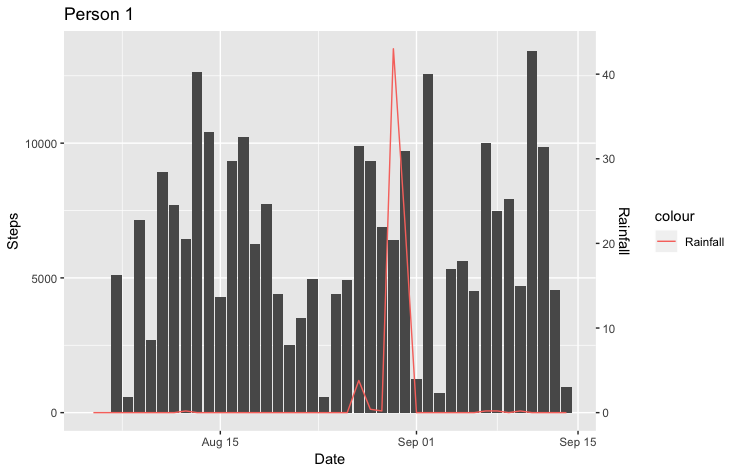

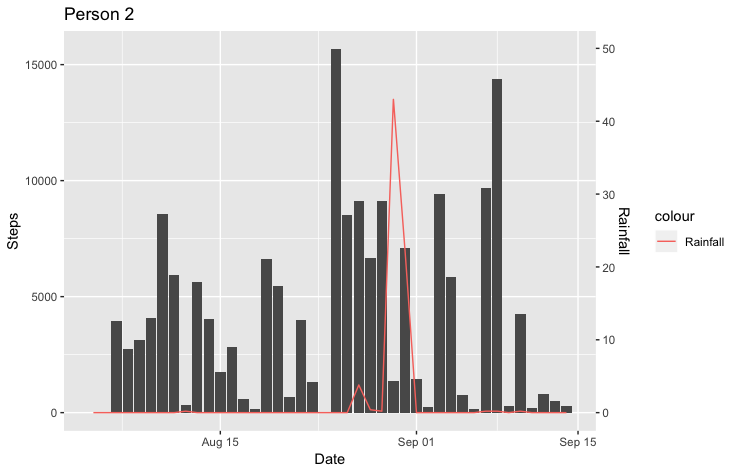

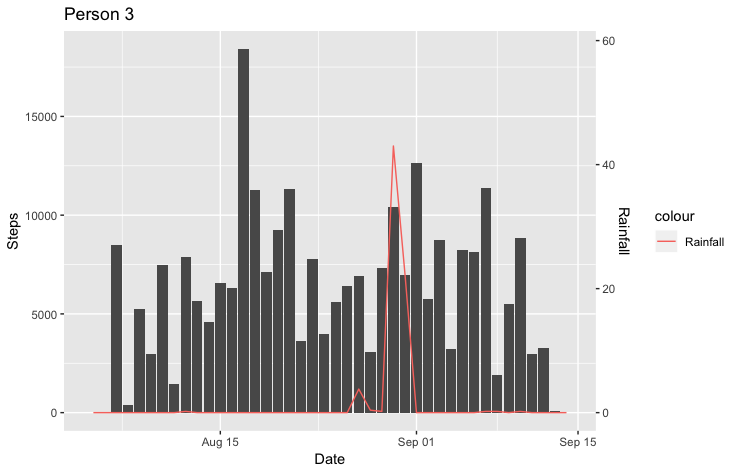

Figure 6: Rainfall vs. Steps count of Individual Members

The plots in Figure 6 indicate that cohort is not particularly concerned about walking when there is a rain. However, it is seems that Person2 had stayed at home during the heavy downpour on August 30th. Aug 31 also had a bit of rain, but as there were classes, everybody had a considerable number of steps.

## 4.4 Happiness Vs Steps

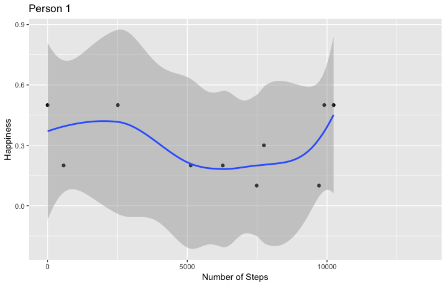

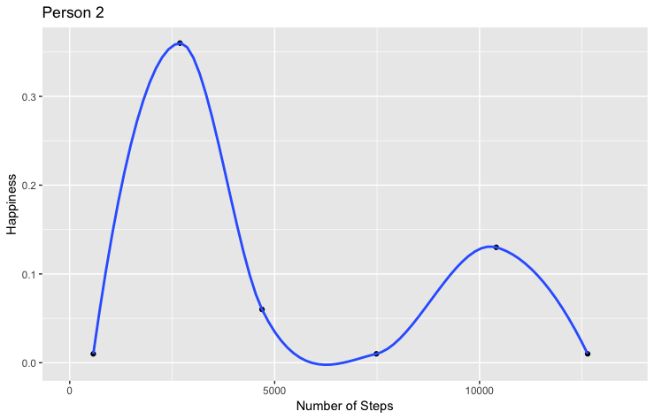

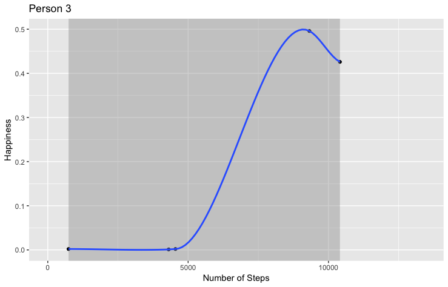

Figure 7: Happiness vs. Steps Count of Individual Members

## 4.5 Individual Analysis

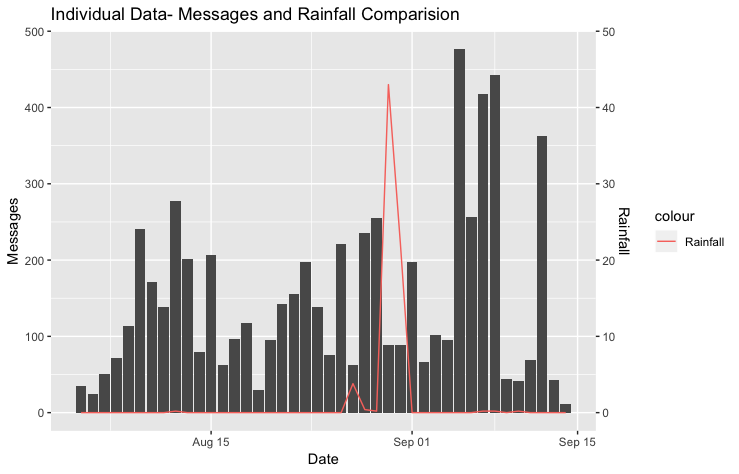

Figure 8: Rainfall vs. Number of Messages

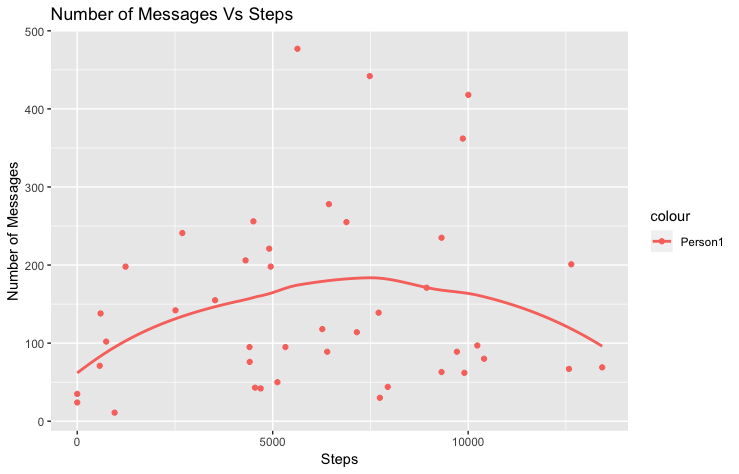

Figure 9: Messages vs. Number of Steps

Figure 9 shows that I tend to be more active on social media when Steps Count is between 5,000 to 10,000. The figure also indicates that more or less steps than average implies less usage of Messenger.

This graph has inspired me to see another plot to check my steps count according to days of the week.

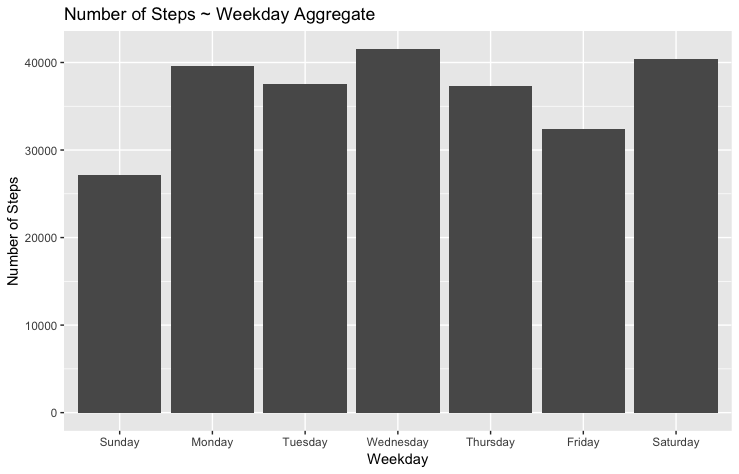

Figure 10: Number of Steps according to Day of Week

Figure 10 shows the aggregated number of steps according to the week day. It shows that the number of steps is less on Sundays, and the most is on Wednesday. Sunday for me is a day to get household chores done, rest and recharge myself for the upcoming week.

# 5. Ethical, Privacy and Legal Issues of the Collected Data

Among collected data, GPS, Messenger and selfie phots leakage could lead to legal issues. GPS and Messenger data can jeopardize a person’s privacy. In case of leakage of GPS data, a person may be stalked by unwanted people. Messenger data leakage is has the capacity to break relationships. Performing analytics on both the data could be used to feed targeted advertisements to people, like the famous Facebook and Cambridge Analytica data scandal (Meredith, 2018). Similarly, the issues with selfie data is that it can be used to make fake videos of people using artificial intelligence. Facial data “can be used to create bogus videos to defame someone, or potentially cause unrest by spreading misinformation on a massive scale”(The Guardian, 2019). Besides these, the steps count and weather data that are used in this report do not have any privacy issues linked with them.

It is thus necessary to use protect data and use them ethically and responsibly. In order to do that, we must make sure that the data that is being used does not hamper the privacy of any other person. (Lee, Wolfgang, & Henry, 2016). Systems must be made secure and be protected from unauthorized access and use. Also, there must be provisions of registering rights to access publicly and privately owned data (Lee, Wolfgang, & Henry, 2016). The GPS data and Google Fit data used in this study were collected from Google could only be extracted by the person of the account. Also, Facebook’s Messenger data could also be only downloaded by the user. Both Facebook and Google required the user to enter password while downloading them. In both their privacy policies, it is written that the entire information could be accessed by government if the user was a part of a government’s investigation.

# 6. Discussion

This project started with mixed thoughts, and the group started looking for data that could be collected, then built questions around them. It would have been a better approach to do a preliminary research and then form questions, followed by data collection. It is also sad to note that during the middle of data collection, two group members dropped out from the course, which impacted the quantity of data collected.

With a small amount of data, relationships were derived just sufficient enough to hint an answer to the initial questions. Not much could be concluded from the cohort’s aggregated data. Stories were created around the analysis to prove the correctness of data, and attempts were made to generalize them.

Nevertheless, this project demended us to gather data, ask questions based on the data, do analysis on it and find out the answers to those questions; a key practice of Data Science. We initially had formulated a list of questions that we were interested to look into in our life. After that, data was collected to check on our questions, making observations on a daily basis and implementing analytics on it, building stories around the analyses and finally trying to answer the questions.

# 7. Reflection and Conclusion

This project has made me realize the power of data and how it can be interpreted and used in personal reflection. There are a lot of factors in our daily life that drive our behaviours, and we tend to ignore them while going through our days. We all would like to be a better version of ourselves, but we are not keeping notice about the minor things that change our behaviour. If we know what we have been doing till date, it will be easy to change some of them and observe their effect on us. Repeated test and observation on ourselves will make sure that we improve our behaviours that go unnoticed. I have seen that our behaviours can be anticipated by data, and with the control over our data, we can control our behaviours.

If this project were to be done again, different sets of data would be taken. Data related to food intake, calorie lost during exercise and sleep patterns would be the best to analyse in my opinion. The GPS data, though was accurate, could not be much of a use in quantifying self except plotting it into a map. Also, more reliable devices such as fitness tracker would be used from next time to track steps and motion more accurately. Lastly, instead of selfies, journal entries would have been a more accurate way to measure the sentiments.

# 8. References

Quantified Self Institute, 2017, *What is quantified self?*, viewed on 20 September 2019, https://qsinstitute.com/about/what-is-quantified-self/

Ferris, T., *The First-Ever Quantified Self Notes (Plus: LSD as Cognitive Enhancer?)*, viewed on 20 September 2019, https://tim.blog/2013/04/03/the-first-ever-quantified-self-notes-plus-lsd-as-cognitive-enhancer/.

Lee, W. W., Z. Wolfgang and C. Henry, 2016, *An Ethical Approach to Data Privacy Protection*,ISACA Journal, Volume 6, 2016, viewed on 21 September 2019, https://www.isaca.org/Journal/archives/2016/volume-6/Pages/an-ethical-approach-to-data-privacy-protection.aspx

Swan, M., 2013, *The Quantified Self: Fundamental Disruption in Big Data Science and Biological Discovery*, viewed on 25th October, 2019, https://www.liebertpub.com/doi/full/10.1089/big.2012.0002

*Data Policy, Facebook*, viewed on 26th October 2019, https://www.facebook.com/policy.php

*Terms and Conditions, Google Fit*, viewed on 26th October 2019, https://developers.google.com/fit/terms

Horowitz, K., 2017, *Why Walking Makes Us Feel Good*, viewed on 27th October 2019, http://mentalfloss.com/article/94677/why-walking-makes-us-feel-good

Meredith, S., 2018, *Here’s everything you need to know about the Cambridge Analytica scandal*, viewed on 27th October 2019, https://www.cnbc.com/2018/03/21/facebook-cambridge-analytica-scandal-everything-you-need-to-know.html

The Guardian, 2019, *Chinese deepfake app Zao sparks privacy row after going viral*, viewed on 27th October 2019, https://www.theguardian.com/technology/2019/sep/02/chinese-face-swap-app-zao-triggers-privacy-fears-viral

# 9. Appendix

## 9.1 Correlations in Group Data

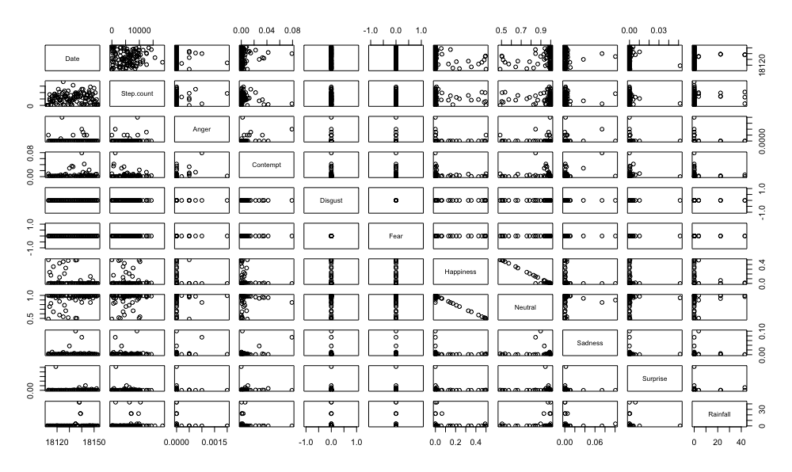

Appendix 1: Correlations in Group Data

## 9.2 Correlations in Individual Data

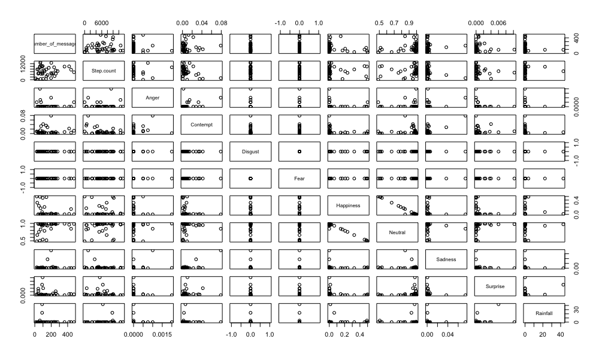

Appendix 2: Correlations in Individual Data

## 9.3 Mood Data Scatter Plots

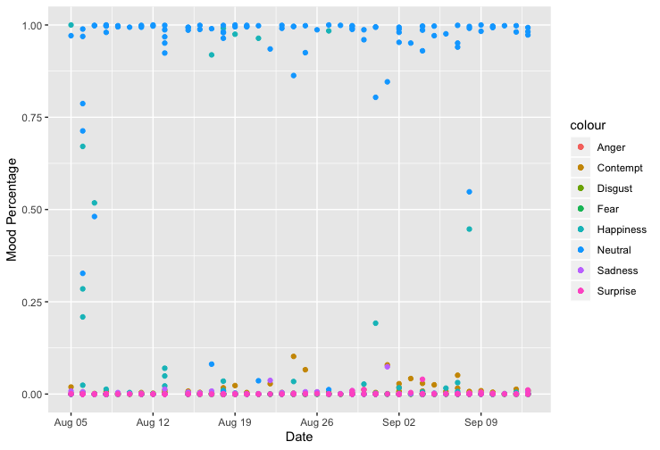

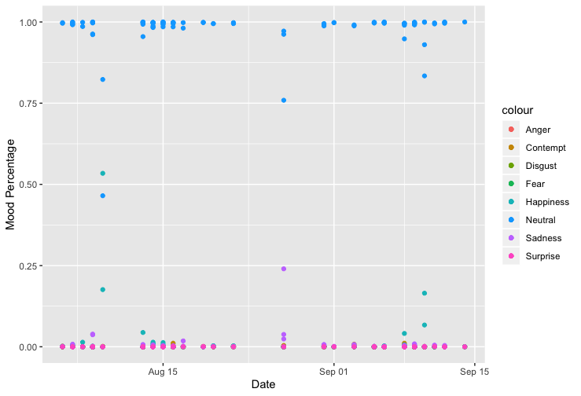

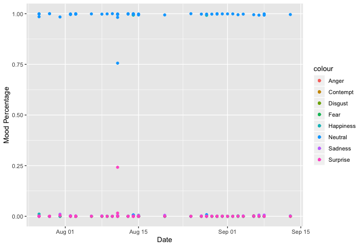

Appendix 3: Mood Data Scatter Plots